# **Final Submission**

# Image Augmentation

We will using image augmentation to see if that Machine Learning technique is able to provide more noise to the data set and potentially improve model performance

```python
# Clearing the backed and setting the random seed


reset_random_seeds
```

```
<function __main__.reset_random_seeds>
```

```python
# Using ImageDataGenerator to generate images

X_train, X_val, y_train, y_val = train_test_split(train_images, train_labels, test_size=0.2, random_state=42)


train_datagen = ImageDataGenerator(horizontal_flip=True,
                                  zoom_range = 0.5, rotation_range=30)
val_datagen  = ImageDataGenerator()

# Flowing training images using train_datagen generator
train_generator = train_datagen.flow(x =train_images, y = train_labels, batch_size=64, seed=42, shuffle=True)

# Flowing validation images using val_datagen generator
val_generator =  val_datagen.flow(x= train_images, y = train_labels, batch_size=64, seed=42, shuffle=True)
```

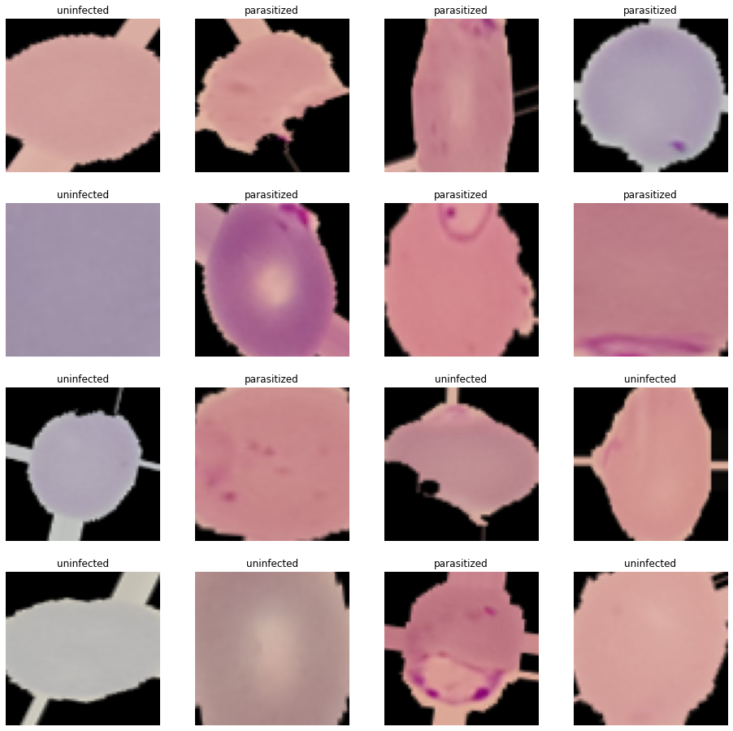

```python
# Visualizing Augmented images

#Creating an iterable for images and labels from the training data
images, labels = next(train_generator)

#Plotting 16 images from the training data
fig, axes = plt.subplots(4, 4, figsize = (16, 8))
fig.set_size_inches(16, 16)
for (image, label, ax) in zip(images, labels, axes.flatten()):
    ax.imshow(image)
    if label[1] == 1:
        ax.set_title('parasitized')
    else:
        ax.set_title('uninfected')
    ax.axis('off')
```

Observations and insights: By using ImageDataGenerator we have significantly altered the images in the dataset. The general circular shape of the blood cell images have been altered. Some images are far more zoomed in. This should provide our models with increased data to use for training, and potentially improve model performance.

Building the Model

```python
model3=Sequential()
model3.add(Conv2D(filters=32,kernel_size=2,padding="same",activation= 'relu',input_shape=(64,64,3)))
model3.add(LeakyReLU(alpha=0.1))
model3.add(MaxPooling2D(pool_size=2))
model3.add(Dropout(0.2))
model3.add(Conv2D(filters=32,kernel_size=2,padding="same",activation="relu"))
model3.add(BatchNormalization())
model3.add(MaxPooling2D(pool_size=2))
model3.add(Dropout(0.2))
model3.add(Conv2D(filters=32,kernel_size=2,padding="same",activation="relu"))
model3.add(BatchNormalization())
model3.add(MaxPooling2D(pool_size=2))
model3.add(Dropout(0.2))


model3.add(Flatten())

model3.add(Dense(512,activation="relu"))
model3.add(Dropout(0.4))
model3.add(Dense(2,activation="softmax"))

adam = optimizers.Adam(learning_rate=0.001)

model3.compile(loss="binary_crossentropy", optimizer=adam, metrics = ['accuracy'])

model3.summary()
```

```
Model: "sequential_3"
_________________________________________________________________
 Layer (type)                Output Shape              Param #
=================================================================
 conv2d_9 (Conv2D)           (None, 64, 64, 32)        416

 leaky_re_lu_3 (LeakyReLU)   (None, 64, 64, 32)        0

 max_pooling2d_9 (MaxPooling  (None, 32, 32, 32)       0
 2D)

 dropout_9 (Dropout)         (None, 32, 32, 32)        0

 conv2d_10 (Conv2D)          (None, 32, 32, 32)        4128

 batch_normalization_3 (Batc  (None, 32, 32, 32)       128
 hNormalization)

 max_pooling2d_10 (MaxPoolin  (None, 16, 16, 32)       0
 g2D)

 dropout_10 (Dropout)        (None, 16, 16, 32)        0

 conv2d_11 (Conv2D)          (None, 16, 16, 32)        4128

 batch_normalization_4 (Batc  (None, 16, 16, 32)       128
 hNormalization)

 max_pooling2d_11 (MaxPoolin  (None, 8, 8, 32)         0
 g2D)

 dropout_11 (Dropout)        (None, 8, 8, 32)          0

 flatten_3 (Flatten)         (None, 2048)              0

 dense_6 (Dense)             (None, 512)               1049088

 dropout_12 (Dropout)        (None, 512)               0

 dense_7 (Dense)             (None, 2)                 1026

=================================================================
Total params: 1,059,042
Trainable params: 1,058,914
Non-trainable params: 128
_________________________________________________________________
```

```python
# Using Callbacks

callbacks = [EarlyStopping(monitor='val_loss', patience=2),
             ModelCheckpoint('.mdl_wts.hdf5', monitor='val_loss', save_best_only=True)]
```

```python
# Fit and Train the Model

history3 = model3.fit(train_generator,
                                  validation_data=val_generator,
                                  batch_size=32,callbacks=callbacks,
                                  epochs=20,verbose=1)
```

```python
# Evaluating the Model on test data

accuracy3 = model3.evaluate(test_images, test_labels, verbose=1)
print('\n', 'Test_Accuracy:-', accuracy3[1])
```

```
 Test_Accuracy:- 0.9792307615280151
```

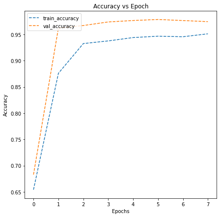

```python
# plotting the accuracies
plot_accuracy(history3)
```

```
              precision    recall  f1-score   support

           0       0.97      0.98      0.98      1300
           1       0.98      0.97      0.98      1300

    accuracy                           0.98      2600
   macro avg       0.98      0.98      0.98      2600
weighted avg       0.98      0.98      0.98      2600
```

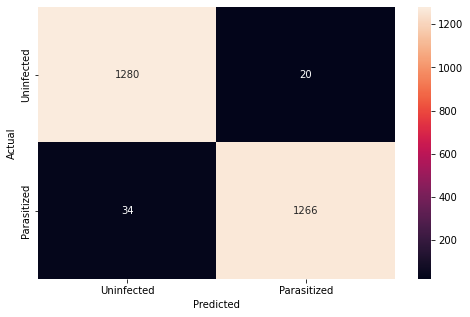

```python
# Plotting the classification report and confusion matrix

pred = model3.predict(test_images)
pred = np.argmax(pred,axis = 1)
y_true = np.argmax(test_labels ,axis = 1)
#Printing the classification report
print(classification_report(y_true, pred))

#Plotting the heatmap using confusion matrix
cm = confusion_matrix(y_true, pred)
plt.figure(figsize=(8,5))
sns.heatmap(cm, annot=True,  fmt='.0f', xticklabels=['Uninfected', 'Parasitized'], yticklabels=['Uninfected', 'Parasitized'])
plt.ylabel('Actual')
plt.xlabel('Predicted')
plt.show()
```

Image augmentation failed to improve model performance

Now let us try to use a pretrained model like VGG16 and check how it performs on our data.

# Pre Trained Model (VGG16)

```python
# Clearing the backed and setting the random seed


reset_random_seeds
```

```
<function __main__.reset_random_seeds>
```

```python
# Building the Model

vgg = VGG16(include_top=False, weights='imagenet', input_shape=(64,64,3))
vgg.summary()
```

```
Model: "vgg16"
_________________________________________________________________
 Layer (type)                Output Shape              Param #
=================================================================
 input_1 (InputLayer)        [(None, 64, 64, 3)]       0

 block1_conv1 (Conv2D)       (None, 64, 64, 64)        1792

 block1_conv2 (Conv2D)       (None, 64, 64, 64)        36928

 block1_pool (MaxPooling2D)  (None, 32, 32, 64)        0

 block2_conv1 (Conv2D)       (None, 32, 32, 128)       73856

 block2_conv2 (Conv2D)       (None, 32, 32, 128)       147584

 block2_pool (MaxPooling2D)  (None, 16, 16, 128)       0

 block3_conv1 (Conv2D)       (None, 16, 16, 256)       295168

 block3_conv2 (Conv2D)       (None, 16, 16, 256)       590080

 block3_conv3 (Conv2D)       (None, 16, 16, 256)       590080

 block3_pool (MaxPooling2D)  (None, 8, 8, 256)         0

 block4_conv1 (Conv2D)       (None, 8, 8, 512)         1180160

 block4_conv2 (Conv2D)       (None, 8, 8, 512)         2359808

 block4_conv3 (Conv2D)       (None, 8, 8, 512)         2359808

 block4_pool (MaxPooling2D)  (None, 4, 4, 512)         0

 block5_conv1 (Conv2D)       (None, 4, 4, 512)         2359808

 block5_conv2 (Conv2D)       (None, 4, 4, 512)         2359808

 block5_conv3 (Conv2D)       (None, 4, 4, 512)         2359808

 block5_pool (MaxPooling2D)  (None, 2, 2, 512)         0

=================================================================
Total params: 14,714,688
Trainable params: 14,714,688
Non-trainable params: 0
_________________________________________________________________
```

```python
transfer_layer = vgg.get_layer('block5_pool')
vgg.trainable=False

# Add classification layers on top of it

x = Flatten()(transfer_layer.output) #Flatten the output from the 3rd block of the VGG16 model
x = Dense(256, activation='relu')(x)

# Similarly add a dense layer with 128 neurons
x = Dropout(0.3)(x)
x = Dense(128, activation='relu')(x)

# Add a dense layer with 64 neurons

x = Dense(64, activation='relu')(x)

x = BatchNormalization()(x)
pred = Dense(2, activation='softmax')(x)

adam = optimizers.Adam(learning_rate=0.001)

model4 = Model(vgg.input, pred) #Initializing the model
```

```python
# Compiling the model

model4.compile(loss="binary_crossentropy", optimizer=adam, metrics = ['accuracy'])
```

```python
# Adding Callbacks to the model

callbacks = [EarlyStopping(monitor='val_loss', patience=2),
             ModelCheckpoint('.mdl_wts.hdf5', monitor='val_loss', save_best_only=True)]
```

```python
#Fitting the model and running the model for 10 epochs
history4 = model4.fit(
            train_images,train_labels,
            epochs=10,
            batch_size=64,
            callbacks = callbacks,
            validation_split=0.2,
            verbose=1)
```

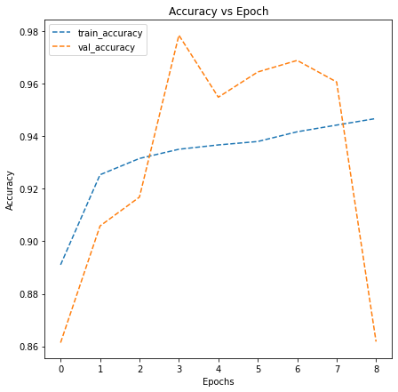

```python
# plotting the accuracies
plot_accuracy(history4)
```

```python
# Evaluating the model on test data
accuracy4 = model4.evaluate(test_images, test_labels, verbose=1)
print('\n', 'Test_Accuracy:-', accuracy4[1])
```

```
 Test_Accuracy:- 0.8834615349769592
```

```
              precision    recall  f1-score   support

           0       0.99      0.78      0.87      1300
           1       0.82      0.99      0.89      1300

    accuracy                           0.88      2600
   macro avg       0.90      0.88      0.88      2600
weighted avg       0.90      0.88      0.88      2600
```

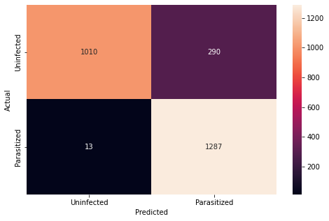

```python
# Plot the confusion matrix and generate a classification report for the model

pred = model4.predict(test_images)
pred = np.argmax(pred,axis = 1)
y_true = np.argmax(test_labels ,axis = 1)
#Printing the classification report
print(classification_report(y_true, pred))

#Plotting the heatmap using confusion matrix
cm = confusion_matrix(y_true, pred)
plt.figure(figsize=(8,5))
sns.heatmap(cm, annot=True,  fmt='.0f', xticklabels=['Uninfected', 'Parasitized'], yticklabels=['Uninfected', 'Parasitized'])
plt.ylabel('Actual')
plt.xlabel('Predicted')
plt.show()
```